# Final Project

# 1 Introduction

In this project, I analyze precipitation trends in Mexican tropical forests using the TerraClimate dataset. TerraClimate comprises monthly climate and climatic water balance for the globe from 1958 to 2015 in a spatial resolution of ~4 km. First, I downloaded the precipitation nc file from the Climatology Lab website. I read the dataset and visualize the first slice with the following R code:

### 1.0.1 Load packages

```r
 # load packages
library(ncdf4)
library(RNetCDF)
library(ncdf.tools)
library(lattice)
library(RColorBrewer)
library(latticeExtra)
library(sf)
library(raster)
library(rasterVis)
library(ggplot2)
library(ggthemes)
```

### 1.0.2 Read data

Printing the nc file provides all the information about the dataset.

```r
# set path and filename
ncpath <- "~/GEOG590/"
ncname <- "agg_terraclimate_ppt_1958_CurrentYear_GLOBE.nc"
ncfname <- paste(ncpath, ncname, sep="")
# open a netCDF file
ncin <- nc_open(ncfname)
print(ncin)
```

```
## File ~/GEOG590/agg_terraclimate_ppt_1958_CurrentYear_GLOBE.nc (NC_FORMAT_CLASSIC):
##
##      1 variables (excluding dimension variables):
##         int ppt[lon,lat,time]
##             _FillValue: NA
##             units: mm
##             description: Accumulated Precipitation
##             long_name: precipitation_amount
##             standard_name: precipitation_amount
##             missing_value: NA
##             dimensions: lon lat time
##             grid_mapping: crs
##             coordinate_system: WGS84,EPSG:4326
##             scale_factor: 0.1
##             add_offset: 0
##             _Unsigned: true
##             _ChunkSizes: 1
##              _ChunkSizes: 540
##              _ChunkSizes: 1080
##             coordinates: time lat lon
##
##      3 dimensions:
##         time  Size:720
##             description: days since 1900-01-01
##             units: days since 1900-01-01 00:00:00
##             long_name: time
##             standard_name: time
##             calendar: gregorian
##             axis: T
##             _ChunkSizes: 12
##             _CoordinateAxisType: Time
##         lat  Size:289
##             units: degrees_north
##             description: Latitude of the center of the grid cell
##             long_name: latitude
##             standard_name: latitude
##             axis: Y
##             _ChunkSizes: 4320
##             _CoordinateAxisType: Lat
##         lon  Size:242
```

[output cut: 45 more lines]

```
##         date_modified: 2018-01-25
##         date_issued: 2018-01-25
##         geospatial_lat_units: decimal degrees north
##         geospatial_lat_resolution: -0.0416666679084301
##         geospatial_lon_units: decimal degrees east
##         geospatial_lon_resolution: 0.0416666679084301
##         geospatial_vertical_units: None
##         geospatial_vertical_resolution: 0
##         geospatial_vertical_positive: Up
##         references: Abatzoglou, J.T., S.Z. Dobrowski, S.A. Parks, and K.C. Hegewisch, 2017, High-resolution global dataset of monthly climate and climatic water balance from 1958-2015, submitted to Scientific Data.
##         source: WorldClim v2.0 (2.5m), CRU Ts4.0, JRA-55
##         version: v1.0
##         Conventions: CF-1.6
##         History: Translated to CF-1.0 Conventions by Netcdf-Java CDM (CFGridWriter2)
## Original Dataset = agg_terraclimate_ppt_1958_CurrentYear_GLOBE.nc; Translation Date = 2019-06-04T20:21:19.574Z
```

### 1.0.3 Get latitude, longitude and time

```r
# get longitude and latitude
lon <- ncvar_get(ncin,"lon")
nlon <- dim(lon)
head(lon)
```

```
## [1] -100.02083  -99.97917  -99.93750  -99.89583  -99.85417  -99.81250
```

```r
lat <- ncvar_get(ncin,"lat")
nlat <- dim(lat)
head(lat)
```

```
## [1] 24.97917 24.93750 24.89583 24.85417 24.81250 24.77083
```

```r
print(c(nlon,nlat))
```

```
## [1] 242 289
```

```r
# get time
time <- ncvar_get(ncin,"time")
head(time); tail(time)
```

```
## [1] 21184 21215 21243 21274 21304 21335
```

```
## [1] 42915 42946 42977 43007 43038 43068
```

```r
tunits <- ncatt_get(ncin,"time","units")
nt <- dim(time)
head(time); tail(time)
```

```
## [1] 21184 21215 21243 21274 21304 21335
```

```
## [1] 42915 42946 42977 43007 43038 43068
```

```r
nt
```

```
## [1] 720
```

```r
# convert time -- split the time units string into fields
tustr <- strsplit(tunits$value, " ")
ptime <- convertDateNcdf2R(time, unlist(tustr)[1], origin = as.POSIXct(unlist(tustr)[3],
                                                                       tz = "UTC"), time.format = "%Y-%m-%d")
head(time); tail(time)
```

```
## [1] 21184 21215 21243 21274 21304 21335
```

```
## [1] 42915 42946 42977 43007 43038 43068
```

```r
head(ptime); tail(ptime)
```

```
## [1] "1958-01-01 UTC" "1958-02-01 UTC" "1958-03-01 UTC" "1958-04-01 UTC" "1958-05-01 UTC" "1958-06-01 UTC"
```

```
## [1] "2017-07-01 UTC" "2017-08-01 UTC" "2017-09-01 UTC" "2017-10-01 UTC" "2017-11-01 UTC" "2017-12-01 UTC"
```

```r
# get data
dname <- "ppt"
ppt_array <- ncvar_get(ncin,dname)
# get attributes of variable
dname <- "ppt"
dlname <- ncatt_get(ncin,dname,"long_name")
dunits <- ncatt_get(ncin,dname,"units")
fillvalue <- ncatt_get(ncin,dname,"_FillValue")
print(c(dlname$value, dunits$value, fillvalue$value))
```

```
## [1] "precipitation_amount" "mm"                   NA
```

```r
dim(ppt_array)
```

```
## [1] 242 289 720
```

```r
# replace netCDF fill values with NA's
ppt_array[ppt_array==fillvalue$value] <- NA
length(na.omit(as.vector(ppt_array[,,1])))
```

```
## [1] 29262
```

# 2 Plot a slice of the array

I used the shapefile of world countries to add an outline.

```r
# set path and shape file name (countries outlines)
shp_path <- "~/GEOG590/shp_files/ne_110m_admin_0_countries/"
shp_name <- "ne_110m_admin_0_countries.shp"
shp_file <- paste(shp_path, shp_name, sep="")
# read the shapefile
world_shp <- read_sf(shp_file)
world_outline <- as(st_geometry(world_shp), Class="Spatial")
```

I selected the first slice, but it is possible to visualize any month of the 60 years

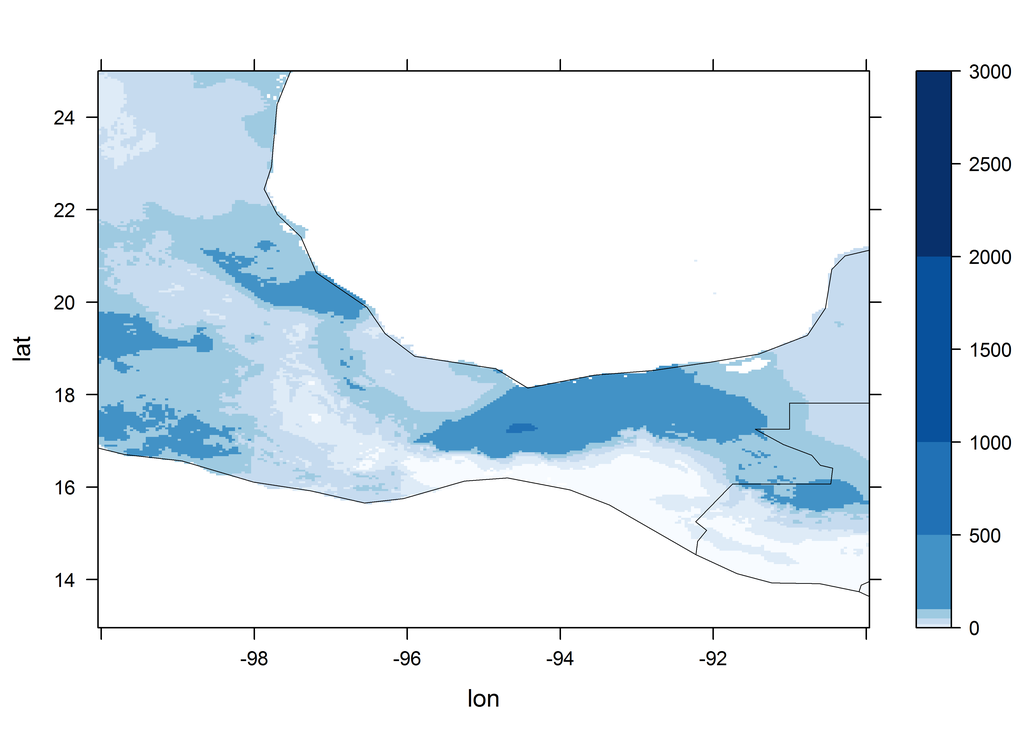

```r
# levelplot of a slice of the array
n <- 1
ppt_slice <- ppt_array[,, n]
grid <- expand.grid(lon=lon, lat=lat)
cutpts <- c(0,5,20,50,100,500,1000,2000,3000)
plt <- levelplot(ppt_slice ~ lon * lat, data=grid, at=cutpts, cuts=11, pretty=T,
                 col.regions=((brewer.pal(9,"Blues"))))
plt + latticeExtra::layer(sp.lines(world_outline, col="black", lwd=0.5))
```

I will get the beginning and ending year of the time series

```r
# get beginning year and ending year, number of years, and set nm
beg_date <- strsplit(as.character(ptime[1]), " ")
beg_yr <- as.numeric(unlist(strsplit(as.character(beg_date), "-"))[1])
end_date <- strsplit(as.character(ptime[nt]), " ")
end_yr <- as.numeric(unlist(strsplit(as.character(end_date), "-"))[1])
nyrs <- end_yr - beg_yr + 1
nm <- 12
print(c(beg_yr, end_yr, nyrs, nm))
```

```
## [1] 1958 2017   60   12
```

# 3 Data analysis and visualization

Research conducted in this region suggest that precipitation during the dry season does not present substantial variation, but the rainy season months have shown a decrease in precipitation. To get an idea of monthly trends, I will plot the average precipitation per month through time.

```r
# generate a decimal year ("YrMn") time coordinate
YrMn <- seq(beg_yr, end_yr+1-(1/12), by=(1/12))
head(YrMn); tail(YrMn)
```

```
## [1] 1958.000 1958.083 1958.167 1958.250 1958.333 1958.417
```

```
## [1] 2017.500 2017.583 2017.667 2017.750 2017.833 2017.917
```

```r
# year
year <- as.integer(YrMn)
head(year); tail(year)
```

```
## [1] 1958 1958 1958 1958 1958 1958
```

```
## [1] 2017 2017 2017 2017 2017 2017
```

```r
# month
month <- rep(seq(1, 12, by=1), nyrs)
month_names <- c("Jan","Feb","Mar","Apr","May","Jun","Jul","Aug","Sep","Oct","Nov", "Dec")
month <- rep(month_names, nyrs)
head(month); tail(month)
```

```
## [1] "Jan" "Feb" "Mar" "Apr" "May" "Jun"
```

```
## [1] "Jul" "Aug" "Sep" "Oct" "Nov" "Dec"
```

```r
month <- factor(month, levels=c("Dec","Jan","Feb","Mar","Apr","May","Jun","Jul","Aug","Sep","Oct","Nov"))
str(month)
```

```
##  Factor w/ 12 levels "Dec","Jan","Feb",..: 2 3 4 5 6 7 8 9 10 11 ...
```

### 3.0.1 Precipitation Trend in two locations

I am interested in studying climatic changes in cloud forest ecosystems. Thus, I will compare the precipitation trends of two different locations of cloud forest.

```r
# get indices of the grid cell closest to Santa Cruz Tepetotutla, Oaxaca (1)
tlon1 <- -96.5593; tlat1 <- 17.7390
j <- which.min(abs(lon-tlon1))
k <- which.min(abs(lat-tlat1))
print(c(j, lon[j], k, lat[k]))
```

```
## [1]  84.00000 -96.56250 175.00000  17.72917
```

Plot the time series:

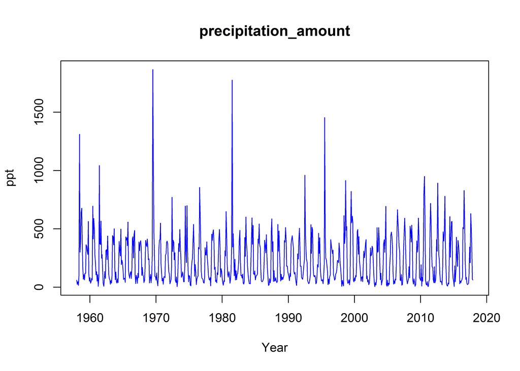

```r
# get time series for the closest gridpoint
ppt_ts <- ppt_array[j, k, ]

# plot time series of grid point
plot(YrMn, ppt_ts, type="l", xlab="Year", ylab=dname, main=dlname$value, col="blue")
```

```r
# get indices of the grid cell closest to Coatepec, Veracruz (2)
tlon2 <- -96.9954; tlat2 <- 19.4583
j2 <- which.min(abs(lon-tlon2))
k2 <- which.min(abs(lat-tlat2))
print(c(j2, lon[j2], k2, lat[k2]))
```

```
## [1]  74.00000 -96.97917 134.00000  19.43750
```

Plot the time series:

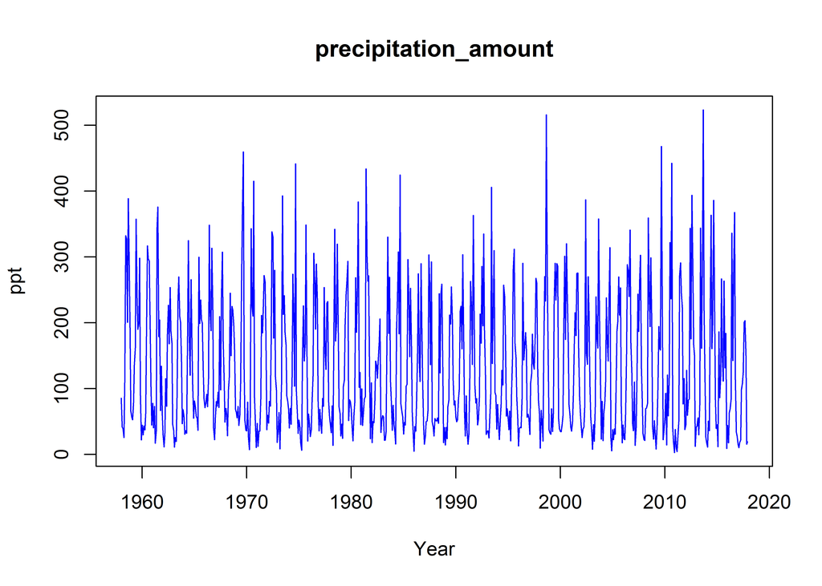

```r
# get time series for the closest gridpoint
ppt_ts2 <- ppt_array[j2, k2, ]

# plot time series of grid point
plot(YrMn, ppt_ts2, type="l", xlab="Year", ylab=dname, main=dlname$value, col="blue")
```

Now, I will plot monthly trends using a multi-panel plot

```r
# make dataframe
ppt_df <- data.frame(YrMn, year, month, ppt_ts)
str(ppt_df)
```

```
## 'data.frame':    720 obs. of  4 variables:
##  $ YrMn  : num  1958 1958 1958 1958 1958 ...
##  $ year  : int  1958 1958 1958 1958 1958 1958 1958 1958 1958 1958 ...
##  $ month : Factor w/ 12 levels "Dec","Jan","Feb",..: 2 3 4 5 6 7 8 9 10 11 ...
##  $ ppt_ts: num  60.5 24.3 47.9 16.1 93.8 ...
```

```r
head(ppt_df); tail(ppt_df)
```

```
##       YrMn year month ppt_ts
## 1 1958.000 1958   Jan   60.5
## 2 1958.083 1958   Feb   24.3
## 3 1958.167 1958   Mar   47.9
## 4 1958.250 1958   Apr   16.1
## 5 1958.333 1958   May   93.8
## 6 1958.417 1958   Jun 1311.1
```

```
##         YrMn year month ppt_ts
## 715 2017.500 2017   Jul  209.7
## 716 2017.583 2017   Aug  630.9
## 717 2017.667 2017   Sep  510.2
## 718 2017.750 2017   Oct  299.7
## 719 2017.833 2017   Nov   67.7
## 720 2017.917 2017   Dec   61.0
```

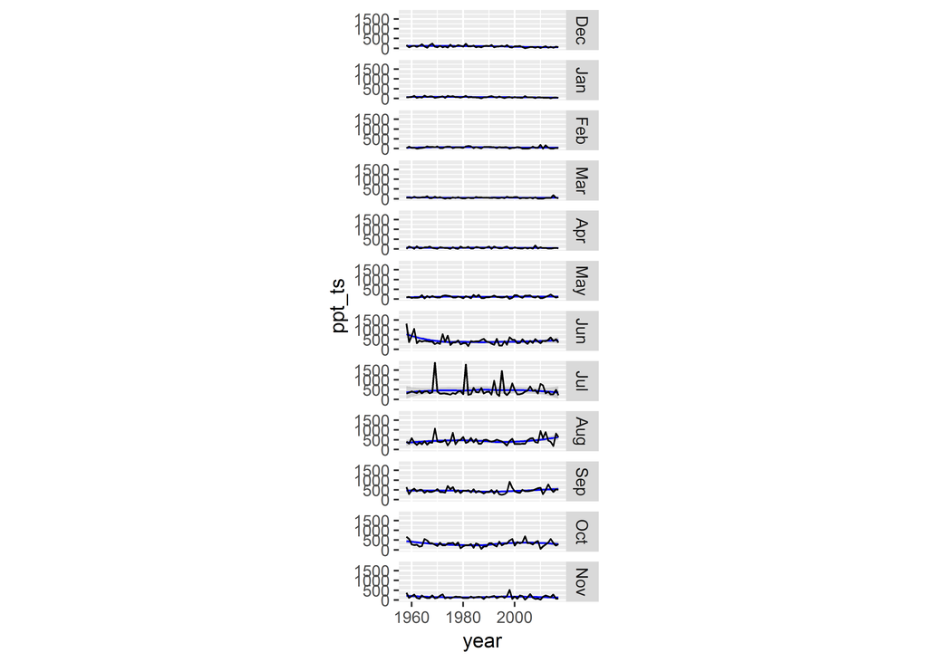

```r
ggplot(data = ppt_df, aes(x=year, y=ppt_ts)) +
  geom_smooth(method = "loess", size=0.5, color="blue") +
  geom_line() +
  facet_grid(month ~ .)+
  theme(aspect.ratio = (0.04 * (nm/2)))
```

```r
# make dataframe
ppt_df2 <- data.frame(YrMn, year, month, ppt_ts2)
str(ppt_df)
```

```
## 'data.frame':    720 obs. of  4 variables:
##  $ YrMn  : num  1958 1958 1958 1958 1958 ...
##  $ year  : int  1958 1958 1958 1958 1958 1958 1958 1958 1958 1958 ...
##  $ month : Factor w/ 12 levels "Dec","Jan","Feb",..: 2 3 4 5 6 7 8 9 10 11 ...
##  $ ppt_ts: num  60.5 24.3 47.9 16.1 93.8 ...
```

```r
head(ppt_df); tail(ppt_df)
```

```
##       YrMn year month ppt_ts
## 1 1958.000 1958   Jan   60.5
## 2 1958.083 1958   Feb   24.3
## 3 1958.167 1958   Mar   47.9
## 4 1958.250 1958   Apr   16.1
## 5 1958.333 1958   May   93.8
## 6 1958.417 1958   Jun 1311.1
```

```
##         YrMn year month ppt_ts
## 715 2017.500 2017   Jul  209.7
## 716 2017.583 2017   Aug  630.9
## 717 2017.667 2017   Sep  510.2
## 718 2017.750 2017   Oct  299.7
## 719 2017.833 2017   Nov   67.7
## 720 2017.917 2017   Dec   61.0
```

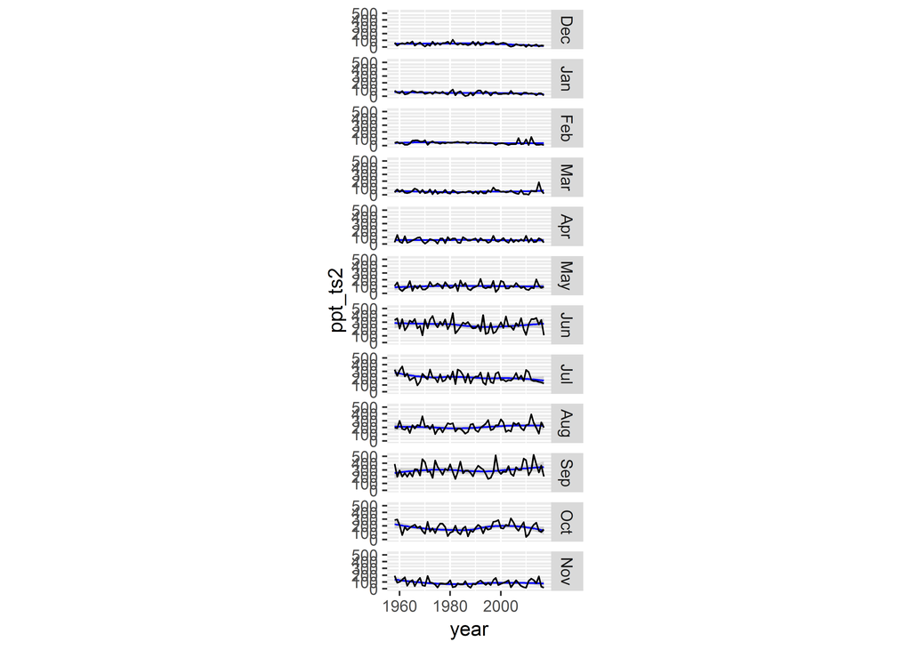

```r
ggplot(data = ppt_df2, aes(x=year, y=ppt_ts2)) +
  geom_smooth(method = "loess", size=0.5, color="blue") +
  geom_line() +
  facet_grid(month ~ .)+
  theme(aspect.ratio = (0.04 * (nm/2)))
```

Next steps: analyze spatial variation.